# Project: Movie Dataset Analysis

- Introduction
- Data Wrangling
- Exploratory Data Analysis
- Conclusions

## Introduction

In this analysis we will be investigating The Movie Dataset which has the data of the movies of the last 50+ years and we'll be looking at the trends and correlation between different data features and how each generation of movies differs from one another. We'll also make our analysis for each decade where required to find better insights.

###### We'll be looking at the following things in our analysis:

Is the data clean? does it contain any zero,null or dupicate values?,

Are all the columns/rows important or are some of them redundant and can be dropped?,

How the popularity and vote_count related and what is their trend in different decades?,

What are the top cast and directors in our dataset?,

Which revenue/budget value to use (revenue/budget-adj or revenue/budget)? Which decade was most profitable?,

What are the most popular genres and keywords of each decade?,

and are all the titles in the dataset "movies"? if no then what other titles exist and how to differentiate them?

```python
# Importing Libraries

import pandas as pd
import seaborn as sns
import matplotlib.pyplot as plt
import csv
import numpy as np
% matplotlib inline
```

```python
# Reading the dataset
df=pd.read_csv('tmdb-movies.csv')
df.head()
```

|  | id | imdb_id | popularity | budget | revenue | original_title | cast | homepage | director | tagline | ... | overview | runtime | genres | production_companies | release_date | vote_count | vote_average | release_year | budget_adj | revenue_adj |
| --- | --- | --- | --- | --- | --- | --- | --- | --- | --- | --- | --- | --- | --- | --- | --- | --- | --- | --- | --- | --- | --- |
| 0 | 135397 | tt0369610 | 32.985763 | 150000000 | 1513528810 | Jurassic World | Chris Pratt\|Bryce Dallas Howard\|Irrfan Khan\|Vi... | http://www.jurassicworld.com/ | Colin Trevorrow | The park is open. | ... | Twenty-two years after the events of Jurassic ... | 124 | Action\|Adventure\|Science Fiction\|Thriller | Universal Studios\|Amblin Entertainment\|Legenda... | 6/9/15 | 5562 | 6.5 | 2015 | 1.379999e+08 | 1.392446e+09 |
| 1 | 76341 | tt1392190 | 28.419936 | 150000000 | 378436354 | Mad Max: Fury Road | Tom Hardy\|Charlize Theron\|Hugh Keays-Byrne\|Nic... | http://www.madmaxmovie.com/ | George Miller | What a Lovely Day. | ... | An apocalyptic story set in the furthest reach... | 120 | Action\|Adventure\|Science Fiction\|Thriller | Village Roadshow Pictures\|Kennedy Miller Produ... | 5/13/15 | 6185 | 7.1 | 2015 | 1.379999e+08 | 3.481613e+08 |
| 2 | 262500 | tt2908446 | 13.112507 | 110000000 | 295238201 | Insurgent | Shailene Woodley\|Theo James\|Kate Winslet\|Ansel... | http://www.thedivergentseries.movie/#insurgent | Robert Schwentke | One Choice Can Destroy You | ... | Beatrice Prior must confront her inner demons ... | 119 | Adventure\|Science Fiction\|Thriller | Summit Entertainment\|Mandeville Films\|Red Wago... | 3/18/15 | 2480 | 6.3 | 2015 | 1.012000e+08 | 2.716190e+08 |
| 3 | 140607 | tt2488496 | 11.173104 | 200000000 | 2068178225 | Star Wars: The Force Awakens | Harrison Ford\|Mark Hamill\|Carrie Fisher\|Adam D... | http://www.starwars.com/films/star-wars-episod... | J.J. Abrams | Every generation has a story. | ... | Thirty years after defeating the Galactic Empi... | 136 | Action\|Adventure\|Science Fiction\|Fantasy | Lucasfilm\|Truenorth Productions\|Bad Robot | 12/15/15 | 5292 | 7.5 | 2015 | 1.839999e+08 | 1.902723e+09 |
| 4 | 168259 | tt2820852 | 9.335014 | 190000000 | 1506249360 | Furious 7 | Vin Diesel\|Paul Walker\|Jason Statham\|Michelle ... | http://www.furious7.com/ | James Wan | Vengeance Hits Home | ... | Deckard Shaw seeks revenge against Dominic Tor... | 137 | Action\|Crime\|Thriller | Universal Pictures\|Original Film\|Media Rights ... | 4/1/15 | 2947 | 7.3 | 2015 | 1.747999e+08 | 1.385749e+09 |

5 rows × 21 columns

## Data Wrangling and Cleaning

In this step we will be converting our data into a more usable format, we will be applying operations to clean,modify and transform our data.

We'll be looking at :

##### Null values : Zero values: Redundant Columns: Duplicate Rows/Columns

```python
#Getting info about the data
print ("Shape of data is: ",df.shape)
print (df.info())
```

```
Shape of data is:  (10866, 21)
<class 'pandas.core.frame.DataFrame'>
RangeIndex: 10866 entries, 0 to 10865
Data columns (total 21 columns):
id                      10866 non-null int64
imdb_id                 10856 non-null object
popularity              10866 non-null float64
budget                  10866 non-null int64
revenue                 10866 non-null int64
original_title          10866 non-null object
cast                    10790 non-null object
homepage                2936 non-null object
director                10822 non-null object
tagline                 8042 non-null object
keywords                9373 non-null object
overview                10862 non-null object
runtime                 10866 non-null int64
genres                  10843 non-null object
production_companies    9836 non-null object
release_date            10866 non-null object
vote_count              10866 non-null int64
vote_average            10866 non-null float64
release_year            10866 non-null int64
budget_adj              10866 non-null float64
revenue_adj             10866 non-null float64
dtypes: float64(4), int64(6), object(11)
memory usage: 1.7+ MB
None
```

As we can see the data has 10866 rows using the shape function, they are many values which are null, these values doesn't help us . Lets see whats the percentage of null values in each column

```python
# Percentage of null values of each column
df.isnull().sum()/len(df)*100
```

```
id                       0.000000
imdb_id                  0.092030
popularity               0.000000
budget                   0.000000
revenue                  0.000000
original_title           0.000000
cast                     0.699429
homepage                72.979937
director                 0.404933
tagline                 25.989324
keywords                13.740107
overview                 0.036812
runtime                  0.000000
genres                   0.211669
production_companies     9.479109
release_date             0.000000
vote_count               0.000000
vote_average             0.000000
release_year             0.000000
budget_adj               0.000000
revenue_adj              0.000000
dtype: float64
```

As we can see the homepage and tagline columns have high percentage of null values, this means these columns are not that useful and these columns are not important for our questions anyway so its better if we just drop them to make our data more compact.Also i think we dont need any analysis to know that the ID and imdb_id have nothing to do with the data.

```python
#Dropping irrelevant columns
df.drop(['homepage'], axis=1, inplace=True)
df.drop(['tagline'],axis=1, inplace=True)
df.drop(['id'], axis=1, inplace=True)
df.drop(['imdb_id'],axis=1, inplace=True)
```

```python
#Printing columns
df.columns
```

```
Index(['popularity', 'budget', 'revenue', 'original_title', 'cast', 'director',
       'keywords', 'overview', 'runtime', 'genres', 'production_companies',
       'release_date', 'vote_count', 'vote_average', 'release_year',
       'budget_adj', 'revenue_adj'],
      dtype='object')
```

Both the "tagline" and "homepage" columns have been removed along with the IDs. As we have removed the top 2 null values columns in terms of percentage there are still many null values present in the dataset.The keywords column and production_companies have higher percentage relative to other columns but we are not sure what to do with them yet.As for other columns with low percentage we cant remove the whole column but we can remove the null value rows since the percentage is low.

```python
#Dropping rows where columns have null values
df.dropna(subset=['cast', 'director','overview','genres'],inplace=True)
```

```python
# Checking null values
df.info()
```

```
<class 'pandas.core.frame.DataFrame'>
Int64Index: 10730 entries, 0 to 10865
Data columns (total 17 columns):
popularity              10730 non-null float64
budget                  10730 non-null int64
revenue                 10730 non-null int64
original_title          10730 non-null object
cast                    10730 non-null object
director                10730 non-null object
keywords                9306 non-null object
overview                10730 non-null object
runtime                 10730 non-null int64
genres                  10730 non-null object
production_companies    9773 non-null object
release_date            10730 non-null object
vote_count              10730 non-null int64
vote_average            10730 non-null float64
release_year            10730 non-null int64
budget_adj              10730 non-null float64
revenue_adj             10730 non-null float64
dtypes: float64(4), int64(5), object(8)
memory usage: 1.5+ MB
```

We can see that we have all the non-null values except keywords and production companies.These two don't have very high percentage of null values for their columns to be dropped and they dont have very low percentage of null values for their rows to be dropped.So we wont change them just yet and see if they would affect our data analysis

Next we are going to check the zero values in the data. Zero values are sometimes correct because an entity can be zero and sometimes data is wrong. Manual work is required here to check if the value is really zero or not.

```python
#checking if columns have any zero values
(df==0).any()
```

```
popularity              False
budget                   True
revenue                  True
original_title          False
cast                    False
director                False
keywords                False
overview                False
runtime                  True
genres                  False
production_companies    False
release_date            False
vote_count              False
vote_average            False
release_year            False
budget_adj               True
revenue_adj              True
dtype: bool
```

budgets and revenues have zero values in them along with runtimes we have to closely look at these values to see if they are right or wrong. Im assuming the revenue_adj and budget_adj are revenues and budgets respectively after adjusting them for inflation so they are more or less the same thing (if we are not interesting in finding inflation rate) and we dont need both of them so lets first check how closely are they related and remove them if they are redundant/duplicate

```python
# zero values in respctive columns of budgets/budget_adj and revenue/revenue_adj
print (df.revenue[df.revenue_adj==0].head(5))
print (df.budget[df.budget_adj==0].head(5))
```

```
48    0
67    0
74    0
75    0
92    0
Name: revenue, dtype: int64
30    0
36    0
72    0
74    0
75    0
Name: budget, dtype: int64
```

We can clearly see that budget is zero where adjusted budget is zero and same for revenue for all values (only few are shown here for better understanding). , lets look at their plots to further prove my assumption

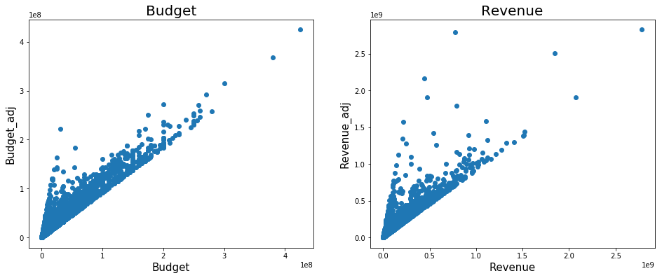

```python
# Plotting budget and budget_adj and revenue with revenue_adj
plt.figure(figsize=(16,6))
plt.subplot(1,2,1)
plt.title('Budget',fontsize="20")
plt.xlabel("Budget",fontsize="15")
plt.ylabel("Budget_adj",fontsize="15")

plt.scatter(x=df.budget,y=df.budget_adj);

plt.subplot(1,2,2)
plt.title('Revenue',fontsize="20")
plt.xlabel("Revenue",fontsize="15")
plt.ylabel("Revenue_adj",fontsize="15")


plt.scatter(x=df.revenue,y=df.revenue_adj);
```

As we can see both are directly proportional with their adjusted values. So as we have deduced that both the "adj" columns of budgets and revenue provide same features as their original column so we can only keep one and still be okay with it so lets just keep the adjusted values because i think its better if we consider inflation in our analysis.

```python
#Dropping redundant columns
df.drop(['revenue'], axis=1, inplace=True)
df.drop(['budget'],axis=1, inplace=True)
```

Still we have some zero values in runtime, revenue_adj and budget_adj lets find their percentage to see how many they are with respect to their column nonzero values

```python
#Percentage of zero values
print ("Percentage of zero values in revenue_adj:   ",len(df[df.revenue_adj==0])/float(len(df.revenue_adj))*100)
print ("Percentage of zero values in budget_adj:   ",len(df[df.budget_adj==0])/float(len(df.budget_adj))*100)
print ("Percentage of zero values in runtime:   ",len(df[df.runtime==0])/float(len(df.runtime))*100)
```

```
Percentage of zero values in revenue_adj:    54.85554520037279
Percentage of zero values in budget_adj:    51.96644920782851
Percentage of zero values in runtime:    0.25163094128611374
```

As revenue and budget have high percentage and by manually checking i can see that these values are not right for the movies, as they have budget and revenues on the internet. so we will replace zero values with mean values because zero values affect the mean/median/mode of data and other statistical operations. An incase of runtime the percentage is small so we are just going to remove the rows.

```python
#removing rows of runtime with zero values
df=df[df.runtime!=0]
#replacing zeros with mean
df['budget_adj']=df['budget_adj'].replace(0,float(df.budget_adj.mean()))
df['revenue_adj']=df['revenue_adj'].replace(0,float(df.revenue_adj.mean()))
```

```python
#Checking zero values
(df==0).any()
```

```
popularity              False
original_title          False
cast                    False
director                False
keywords                False
overview                False
runtime                 False
genres                  False
production_companies    False
release_date            False
vote_count              False
vote_average            False
release_year            False
budget_adj              False
revenue_adj             False
dtype: bool
```

We can see all the columns have non zero values

Last we check if there are any duplicates in data and dropping them

```python
# finding duplicates
df[df.duplicated()==True]
```

|  | popularity | original_title | cast | director | keywords | overview | runtime | genres | production_companies | release_date | vote_count | vote_average | release_year | budget_adj | revenue_adj |
| --- | --- | --- | --- | --- | --- | --- | --- | --- | --- | --- | --- | --- | --- | --- | --- |
| 2090 | 0.59643 | TEKKEN | Jon Foo\|Kelly Overton\|Cary-Hiroyuki Tagawa\|Ian... | Dwight H. Little | martial arts\|dystopia\|based on video game\|mart... | In the year of 2039, after World Wars destroy ... | 92 | Crime\|Drama\|Action\|Thriller\|Science Fiction | Namco\|Light Song Films | 3/20/10 | 110 | 5.0 | 2010 | 30000000.0 | 967000.0 |

```python
#dropping duplicates
df.drop_duplicates(keep=False, inplace=True)
# finding duplicates
df[df.duplicated()==True]
```

|  | popularity | original_title | cast | director | keywords | overview | runtime | genres | production_companies | release_date | vote_count | vote_average | release_year | budget_adj | revenue_adj |
| --- | --- | --- | --- | --- | --- | --- | --- | --- | --- | --- | --- | --- | --- | --- | --- |

### Data Wrangling Conclusion

Following steps were taked in data wrangling process:

1) Drop Columns with high percentage of null values

2) Drop Rows of null values where percentage was low

3) Replacing Zero values with mean where values were large

4) Dropping Zero values where values were low

5) Dropping Duplicates

6) Dropping redundant columns

## Exploratory Data Analysis

##### Here we will explore the dataset and ask questions about the characteristics of the data and their visualizations.

Following are the questions which we will ask:

Q1) How has the popularity and vote count increased in the last few decades.

Q2) Which decade was the most successful monetarily?

Q3) What are the most popular genres and keywords of the last decade

Q4) Which director and actor/actress has been the most successful?

Q5) What is the ratio of movies and tv-series in the dataset ? How to differentiate.

### Research Question 1:

#### How has the popularity and vote count increased in the last few decades.

Lets first find the correlation between popularity and vote_count because they look almost similar and it would be interesting.

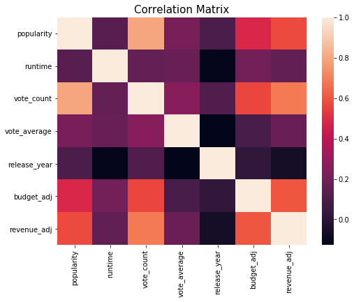

```python
#Correlation Matrix
plt.figure(figsize=(8,6))
corr=df.corr()
plt.title("Correlation Matrix",fontsize="15")
sns.heatmap(corr,
            xticklabels=corr.columns.values,
            yticklabels=corr.columns.values);
```

From the heatmap we can see that the correlation between popularity and vote_count is in 0.8 range which is good for our cause.Lets plot them.

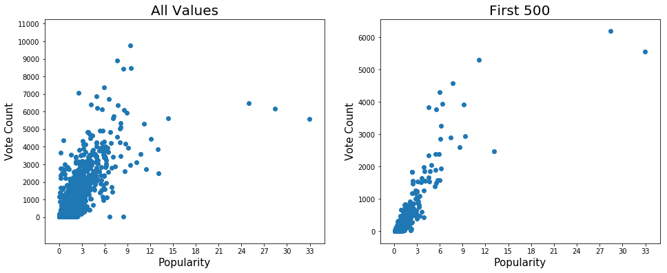

```python
#plotting all values
plt.figure(figsize=(16,6))
plt.subplot(1,2,1)
plt.title('All Values',fontsize="20")
plt.xlabel("Popularity",fontsize="15")
plt.ylabel("Vote Count",fontsize="15")
plt.yticks(np.arange(0, 100001, step=1000))
plt.xticks(np.arange(0, 35, step=3))

plt.scatter(x=df.popularity,y=df.vote_count)
#plotting just first 100 values
plt.subplot(1,2,2)
plt.title('First 500',fontsize="20")
plt.xlabel("Popularity",fontsize="15")
plt.ylabel("Vote Count",fontsize="15")
plt.xticks(np.arange(0, 35, step=3))
plt.yticks(np.arange(0, 7001, step=1000))

plt.scatter(x=df.popularity.head(500),y=df.vote_count.head(500));
```

Both plots are showing even vote_Count and popularity are directly proportional to each other to some extent which makes sense as the number of voters increases popularity generally. We can see that the popularity has some outliers it would be better if we clean this data.

#### Popularity

```python
df.popularity.describe()
```

```
count    10701.000000
mean         0.653859
std          1.005775
min          0.000188
25%          0.211508
50%          0.388036
75%          0.722465
max         32.985763
Name: popularity, dtype: float64
```

75% of popularity values are less than 1 but the max value is 32 which makes are plot uneven. So, lets remove the outliers

```python
q=df.popularity.quantile(0.99)
df=df[df.popularity<q]
```

```python
df.popularity.describe()
```

```
count    10593.000000
mean         0.586488
std          0.628073
min          0.000188
25%          0.210293
50%          0.384763
75%          0.706023
max          4.586426
Name: popularity, dtype: float64
```

Only removing 1% of outliers made our data cleaner, now lets plot the graphs again

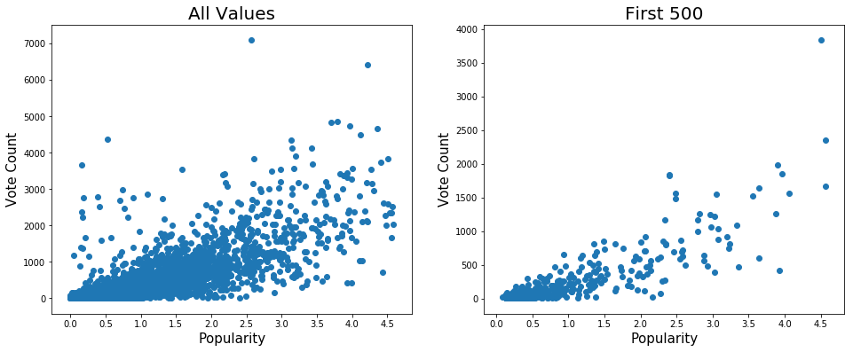

```python
#plotting all values
plt.figure(figsize=(16,6))
plt.subplot(1,2,1)
plt.title('All Values',fontsize="20")
plt.xlabel("Popularity",fontsize="15")
plt.ylabel("Vote Count",fontsize="15")
plt.xticks(np.arange(0, 5, step=0.5))
plt.yticks(np.arange(0, 8001, step=1000))

plt.scatter(x=df.popularity,y=df.vote_count)
#plotting just first 100 values
plt.subplot(1,2,2)
plt.title('First 500',fontsize="20")
plt.xlabel("Popularity",fontsize="15")
plt.ylabel("Vote Count",fontsize="15")
plt.xticks(np.arange(0, 5, step=0.5))
plt.yticks(np.arange(0, 4001, step=500))

plt.scatter(x=df.popularity.head(500),y=df.vote_count.head(500));
```

Now we get better distribution of the data but still popularity and vote count have a positive correlation. Now lets find their stats for each decade, first lets divide decade into bins

```python
df['decades']=pd.cut(df['release_year'],[1960,1970,1980,1990,2000,2010,2020],right=False)
```

Now lets find what is the the average popularity throughout the decade for each decade

```python
decade_popularity=df.groupby(['decades']).popularity.mean()
decade_popularity=decade_popularity.to_frame('Popularity')
decade_popularity
```

| decades | Popularity |
| --- | --- |
| [1960, 1970) | 0.428118 |
| [1970, 1980) | 0.444115 |
| [1980, 1990) | 0.508504 |
| [1990, 2000) | 0.593464 |
| [2000, 2010) | 0.601830 |
| [2010, 2020) | 0.628450 |

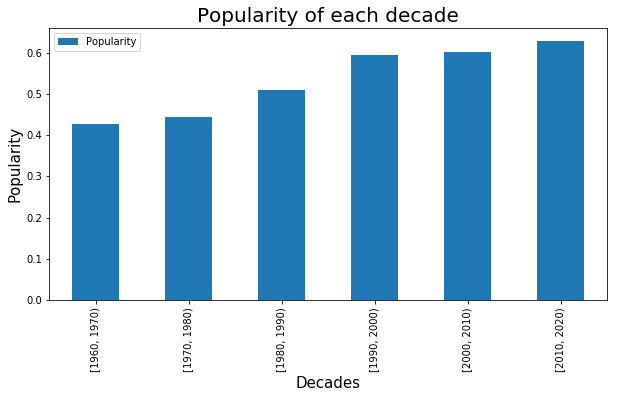

```python
decade_popularity.plot(kind="bar",figsize=(10,5),legend=True)
plt.title('Popularity of each decade',fontsize="20")
plt.xlabel("Decades",fontsize="15")
plt.ylabel("Popularity",fontsize="15")
plt.show()
```

We can clearly see from the data and the graph that popularity is increasing with time meaning that people of this generation are more interested in movies than previou/s generations.

Now lets do the same for vote count

#### Vote_Count:

```python
decade_vote=df.groupby(['decades']).vote_count.mean()
decade_vote=decade_vote.to_frame("Votes")
decade_vote
```

| decades | Votes |
| --- | --- |
| [1960, 1970) | 71.251397 |
| [1970, 1980) | 88.284861 |
| [1980, 1990) | 111.298095 |
| [1990, 2000) | 160.264269 |
| [2000, 2010) | 197.083858 |
| [2010, 2020) | 233.520512 |

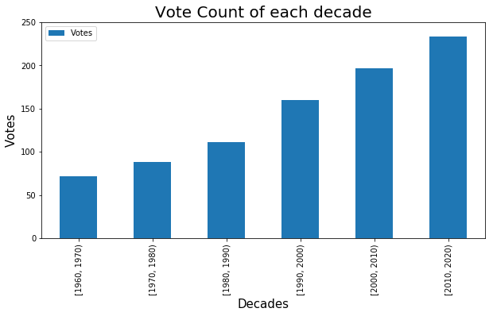

```python
decade_vote.plot(kind="bar",figsize=(10,5),legend=True)
plt.title('Vote Count of each decade',fontsize="20")
plt.xlabel("Decades",fontsize="15")
plt.yticks(np.arange(0, 300, step=50))

plt.ylabel("Votes",fontsize="15")
plt.show()
```

And as proven above the graph and data for vote_count is similar to popularity i.e people of current decade vote more than previous generations.

### Research Question 2

#### Which decade was the most successful monetarily?

As we are dividing generations by decades so we will use the same decades(bins) column as above to show revenue_adj(Earned) and budget_adj(cost). Adjusted values are used so that the comparision makes some sense because money value is not the same in each decade.

###### Revenue

```python
#to show large numbers
pd.options.display.float_format = '{:.4f}'.format

#groupby each decade and sum of revenues of that group
decade_revenue=df.groupby(['decades']).revenue_adj.sum()
decade_revenues=decade_revenue.to_frame('Revenue')
decade_revenues
```

| decades | Revenue |
| --- | --- |
| [1960, 1970) | 34881824860.5288 |
| [1970, 1980) | 54665854522.4536 |
| [1980, 1990) | 79767389478.3975 |
| [1990, 2000) | 151477968510.9974 |
| [2000, 2010) | 262069838405.4179 |
| [2010, 2020) | 212051254499.0825 |

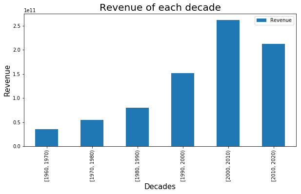

```python
plt.show()
decade_revenues.plot(kind="bar",figsize=(10,5),legend=True)
plt.title('Revenue of each decade',fontsize="20")
plt.xlabel("Decades",fontsize="15")
plt.ylabel("Revenue",fontsize="15")

plt.show()
```

The revenues of movies get larger as the year increases. The current generation has only 5 year data for that decade but still its in the second place, which tells you the revenue is growing stronger and stronger each year.

###### Budget

```python
#groupby each decade and sum of budgets of that group

decade_budget=df.groupby(['decades']).budget_adj.sum()
decade_budgets=decade_budget.to_frame("Budget")
decade_budgets
```

| decades | Budget |
| --- | --- |
| [1960, 1970) | 8111373406.9956 |
| [1970, 1980) | 10007221683.4289 |
| [1980, 1990) | 23002704857.3082 |
| [1990, 2000) | 55986321105.9445 |
| [2000, 2010) | 103321643923.2535 |
| [2010, 2020) | 76916283826.4143 |

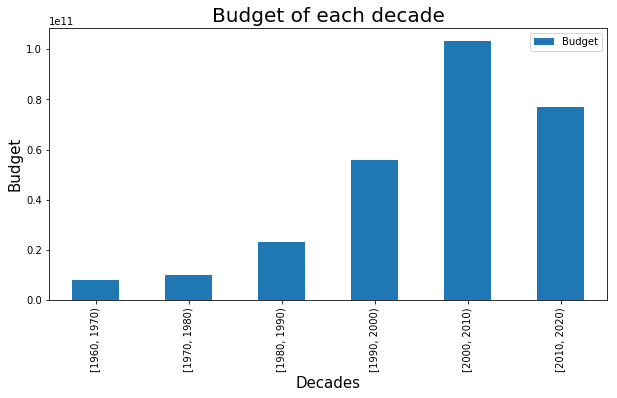

```python
plt.show()
decade_budgets.plot(kind="bar",figsize=(10,5),legend=True)
plt.title('Budget of each decade',fontsize="20")
plt.xlabel("Decades",fontsize="15")
plt.ylabel("Budget",fontsize="15")
plt.show()
```

Same as revenue the Budget increases with years, the highest is 2000-2010 which was the last decade, the current decade is second because we only have values till year 2015 in our data.

Both revenue and budget show a trend that with increasing year the values will grow. It will cost more to make a movie but you will also earn more making a movie compared to previous year. To gain better knowledge if movie buissness is moving towards more profit or less profit we can take ratio of revenue and budget sums.

```python
#Profit
profit=(decade_revenue/decade_budget)
profit=profit.to_frame('Profit Ratio')
profit
```

| decades | Profit Ratio |
| --- | --- |
| [1960, 1970) | 4.3004 |
| [1970, 1980) | 5.4626 |
| [1980, 1990) | 3.4677 |
| [1990, 2000) | 2.7056 |
| [2000, 2010) | 2.5364 |
| [2010, 2020) | 2.7569 |

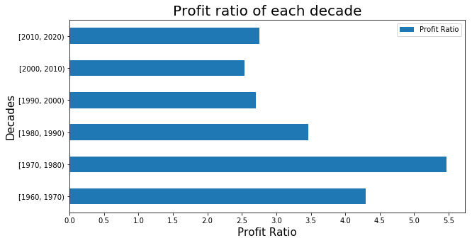

```python
profit.plot(kind="barh",figsize=(10,5),legend=True)
plt.title('Profit ratio of each decade',fontsize="20")
plt.xlabel("Profit Ratio",fontsize="15")
plt.ylabel("Decades",fontsize="15")
plt.xticks(np.arange(0, 6, step=0.5))

plt.show()
```

This tells us that even with high revenue you cannot say that the profit is high coz budget is also high. The decade 1970-80 has one of the lowest revenues but it has the best profit rate out of them all.Profit rate is slightly decreasing with years so it means the return on investment on movies is not as much as it was in the past.

### Research Question 3

#### What are the most popular genres and keywords of the last decade

Lets find the most popular genres first.

#### Genre

```python
df.genres.head()
```

```
25                             Action
26                             Comedy
27      Crime|Comedy|Action|Adventure
28             Drama|Thriller|History
29    Action|Science Fiction|Thriller
Name: genres, dtype: object
```

As you can see a single row of genres column has multiple values so we have to seperate it to make it useful to us.

```python
# splitting genres on |
g=df[['genres','release_year']].apply(lambda x:[(n,x[1]) for n in x[0].split('|')],axis=1)
all_genres=[]
# appending all genres into a list
g.apply(lambda x:[all_genres.append(n) for n in x])
#making a new dataframe
genres_df=pd.DataFrame(all_genres,columns=['genres','year'])
```

Now that all genre values are independent we can use them.To find most popular genres of each decade we will use the same decade bins we used for popularity and vote count but due to multiple values in each row the quantity of bins will be increased.

```python
genres_df['genre_bins']=pd.cut(genres_df.year,bins=[1960,1970,1980,1990,2000,2010,2020],right=False)
genres_df.genre_bins.head()
```

```
0    [2010, 2020)
1    [2010, 2020)
2    [2010, 2020)
3    [2010, 2020)
4    [2010, 2020)
Name: genre_bins, dtype: category
Categories (6, interval[int64]): [[1960, 1970) < [1970, 1980) < [1980, 1990) < [1990, 2000) < [2000, 2010) < [2010, 2020)]
```

First i will have to groupby genres by their decade bins after that i have to count the number of occurences of each genre in each decade,then sorting the values on the number of count would give me better understanding of the data.For simplicity i am going to use the top 3 values of each decade.

```python
# function to find the occurences of genres and then using those occurences to sort
def func(df):
    return df.groupby('genres').size().to_frame('count').sort_values(by='count',ascending=False).iloc[:3]

# groupby each decade and using the count function to find top 3 occurences of each decade
genre_graph=genres_df.groupby(['genre_bins']).apply(func)
genre_graph
```

| genre_bins | genres | count |
| --- | --- | --- |
| [1960, 1970) | Drama | 167 |
|  | Comedy | 112 |
|  | Action | 78 |
| [1970, 1980) | Drama | 237 |
|  | Thriller | 147 |
|  | Comedy | 121 |
| [1980, 1990) | Comedy | 427 |
|  | Drama | 421 |
|  | Action | 268 |
| [1990, 2000) | Drama | 858 |
|  | Comedy | 734 |
|  | Thriller | 493 |
| [2000, 2010) | Drama | 1602 |
|  | Comedy | 1345 |
|  | Thriller | 967 |
| [2010, 2020) | Drama | 1421 |
|  | Comedy | 1010 |
|  | Thriller | 936 |

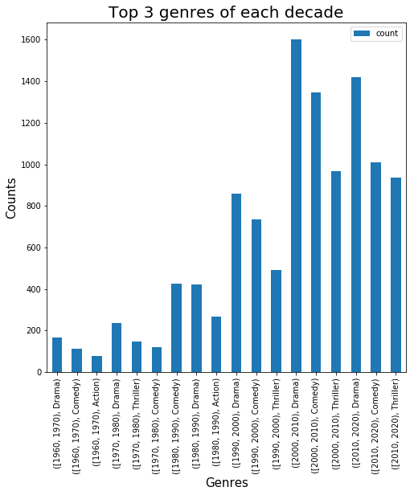

```python
genre_graph.plot(kind='bar',figsize=(8,8),legend=True);
plt.title('Top 3 genres of each decade',fontsize="20")
plt.xlabel("Genres",fontsize="15")
plt.ylabel("Counts",fontsize="15")
plt.show()
```

#### Keywords

We can find most popular keywords like the genre method but keywords have null values, so lets remove the null values that we have and compute because we cant do it any other way.

```python
df.info()
```

```
<class 'pandas.core.frame.DataFrame'>
Int64Index: 10593 entries, 25 to 10865
Data columns (total 16 columns):
popularity              10593 non-null float64
original_title          10593 non-null object
cast                    10593 non-null object
director                10593 non-null object
keywords                9184 non-null object
overview                10593 non-null object
runtime                 10593 non-null int64
genres                  10593 non-null object
production_companies    9652 non-null object
release_date            10593 non-null object
vote_count              10593 non-null int64
vote_average            10593 non-null float64
release_year            10593 non-null int64
budget_adj              10593 non-null float64
revenue_adj             10593 non-null float64
decades                 10593 non-null category
dtypes: category(1), float64(4), int64(3), object(8)
memory usage: 1.3+ MB
```

```python
df_keyword=df.dropna(subset=['keywords'])
df_keyword.info()
```

```
<class 'pandas.core.frame.DataFrame'>
Int64Index: 9184 entries, 25 to 10865
Data columns (total 16 columns):
popularity              9184 non-null float64
original_title          9184 non-null object
cast                    9184 non-null object
director                9184 non-null object
keywords                9184 non-null object
overview                9184 non-null object
runtime                 9184 non-null int64
genres                  9184 non-null object
production_companies    8552 non-null object
release_date            9184 non-null object
vote_count              9184 non-null int64
vote_average            9184 non-null float64
release_year            9184 non-null int64
budget_adj              9184 non-null float64
revenue_adj             9184 non-null float64
decades                 9184 non-null category
dtypes: category(1), float64(4), int64(3), object(8)
memory usage: 1.1+ MB
```

Now as all the keywords null values have been removed,we can use the genre method

```python
# splitting keywords on |
k=df_keyword[['keywords','release_year']].apply(lambda x:[(n,x[1]) for n in x[0].split('|')],axis=1)
all_keywords=[]
# appending all genres into a list
k.apply(lambda x:[all_keywords.append(n) for n in x])
#making a new dataframe
keywords_df=pd.DataFrame(all_keywords,columns=['keywords','year'])

keywords_df['keyword_bins']=pd.cut(keywords_df.year,bins=[1960,1970,1980,1990,2000,2010,2020],right=False)
# function to find the occurences of keywords and then using those occurences to sort
def func(df):
    return df.groupby('keywords').size().to_frame('count').sort_values(by='count',ascending=False).iloc[:3]

# groupby each decade and using the count function to find top 3 occurences of each decade
keywords_graph=keywords_df.groupby(['keyword_bins']).apply(func)
keywords_graph
```

| keyword_bins | keywords | count |
| --- | --- | --- |
| [1960, 1970) | based on novel | 16 |
|  | england | 15 |
|  | london | 13 |
| [1970, 1980) | based on novel | 23 |
|  | female nudity | 18 |
|  | suspense | 18 |
| [1980, 1990) | nudity | 39 |
|  | sex | 36 |
|  | female nudity | 34 |
| [1990, 2000) | independent film | 80 |
|  | sex | 51 |
|  | sport | 49 |
| [2000, 2010) | independent film | 214 |
|  | sex | 121 |
|  | woman director | 119 |
| [2010, 2020) | woman director | 226 |
|  | biography | 95 |
|  | based on novel | 93 |

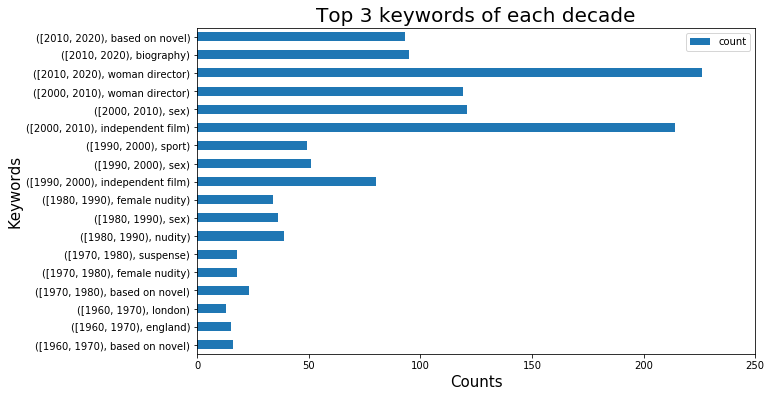

```python
keywords_graph.plot(kind='barh',figsize=(10,6),legend=True,title='Top 3 keyowrds of each decade')
plt.title('Top 3 keywords of each decade',fontsize="20")
plt.xlabel("Counts",fontsize="15")
plt.ylabel("Keywords",fontsize="15")
plt.xticks(np.arange(0, 300, step=50))

plt.show()
```

This is a very interesting insight as it provides the keywords of the movies of diffferent generations and all are telling different things. The earlier decade movies were based on novels then the main focus was on nudity and fornication in the middle decades and then with women empowerment, the women directors emerge as the clear leaders in the recent decades.

### Research Question 4

#### Which director and actor/actress has been the most successful?

##### Director

To find the most successful director lets find the directors with most number of movies

```python
# top directors with most movies
df.groupby(['director']).size().sort_values(ascending =False).iloc[:5]
```

```
director
Woody Allen          45
Clint Eastwood       34
Steven Spielberg     29
Martin Scorsese      27
Steven Soderbergh    22
dtype: int64
```

These are the top 5 directors with most movies but it doesn't mean that they are successful , because a number of their movies can be flops.So,lets see which director has earned the most revenues.

```python
# top directors with most revenue
df.groupby(['director']).revenue_adj.sum().sort_values(ascending =False).iloc[:5]
```

```
director
Steven Spielberg   15306731532.0330
Michael Bay         5234544105.2757
Ron Howard          4735664972.6137
James Cameron       4387735037.2228
Roland Emmerich     4181265738.8914
Name: revenue_adj, dtype: float64
```

Even this could be misleading as one bad director could make a lot of movies and increase its total sum, so we should take the mean of revenues

```python
# Finding directors with highest mean with atleast 5 movies
direct=df.groupby(['director']).revenue_adj.mean()[df.groupby(['director']).size()>5]
direct.sort_values(ascending =False).iloc[:5]
```

```
director
James Cameron      626819291.0318
Steven Spielberg   527818328.6908
Michael Bay        523454410.5276
Roland Emmerich    380115067.1719
Justin Lin         326134365.1195
Name: revenue_adj, dtype: float64
```

Even this doesn't tell the whole picture as the directors with 1 good movie would have the higher than a director with 6 good movies and 1 bad movie, so we should take both the counts of movies and means to generate our final output.

```python
df.groupby(['director']).revenue_adj.mean().sort_values(ascending =False).iloc[:5]
```

```
director
Clyde Geronimi|Hamilton Luske|Wolfgang Reitherman   1574814739.7048
Lee Unkrich                                         1063171911.0000
Andrew Adamson|Kelly Asbury|Conrad Vernon           1061903622.7420
Andrew Stanton|Lee Unkrich                          1024886689.7700
Chris Miller|Raman Hui                               840239200.9675
Name: revenue_adj, dtype: float64
```

#### Cast

```python
df.cast.head()
```

```
25    Tom Cruise|Jeremy Renner|Simon Pegg|Rebecca Fe...
26    Mark Wahlberg|Seth MacFarlane|Amanda Seyfried|...
27    Taron Egerton|Colin Firth|Samuel L. Jackson|Mi...
28    Mark Ruffalo|Michael Keaton|Rachel McAdams|Lie...
29    Dylan O'Brien|Kaya Scodelario|Thomas Brodie-Sa...
Name: cast, dtype: object
```

We can see that a movie has multiple casts like genres so we perform the same operation for it as well.

```python
# splitting cast on |
c=df[['cast','release_year','revenue_adj']].apply(lambda x:[(n,x[1],x[2]) for n in x[0].split('|')],axis=1)
all_cast=[]
# appending all cast into a list
c.apply(lambda x:[all_cast.append(n) for n in x])
#making a new dataframe
cast_df=pd.DataFrame(all_cast,columns=['cast','year','revenue'])
cast_df.head(20)
```

|  | cast | year | revenue |
| --- | --- | --- | --- |
| 0 | Tom Cruise | 2015 | 627743451.6729 |
| 1 | Jeremy Renner | 2015 | 627743451.6729 |
| 2 | Simon Pegg | 2015 | 627743451.6729 |
| 3 | Rebecca Ferguson | 2015 | 627743451.6729 |
| 4 | Ving Rhames | 2015 | 627743451.6729 |
| 5 | Mark Wahlberg | 2015 | 198594430.1384 |
| 6 | Seth MacFarlane | 2015 | 198594430.1384 |
| 7 | Amanda Seyfried | 2015 | 198594430.1384 |
| 8 | Jessica Barth | 2015 | 198594430.1384 |
| 9 | Giovanni Ribisi | 2015 | 198594430.1384 |
| 10 | Taron Egerton | 2015 | 371497801.6610 |
| 11 | Colin Firth | 2015 | 371497801.6610 |
| 12 | Samuel L. Jackson | 2015 | 371497801.6610 |
| 13 | Michael Caine | 2015 | 371497801.6610 |
| 14 | Mark Strong | 2015 | 371497801.6610 |
| 15 | Mark Ruffalo | 2015 | 81278719.3974 |
| 16 | Michael Keaton | 2015 | 81278719.3974 |
| 17 | Rachel McAdams | 2015 | 81278719.3974 |
| 18 | Liev Schreiber | 2015 | 81278719.3974 |
| 19 | John Slattery | 2015 | 81278719.3974 |

Now that we've seperate the cast into each independent row like genre we can use the same operations we used for director to find most successful actor/actress.As many cast make more than 20 movies so we change our threshold to 20.

```python
direct=cast_df.groupby(['cast']).revenue.mean()[cast_df.groupby(['cast']).size()>20]
direct.sort_values(ascending =False).iloc[:10]
```

```
cast
Will Smith          358178517.7555
Tom Cruise          307276415.1716
Richard Dreyfuss    237855148.9457
Tom Hanks           225429626.5552
Cameron Diaz        222450346.5196
Leonardo DiCaprio   215983968.2786
Eddie Murphy        214036394.9093
Ben Stiller         208266944.7656
Sean Connery        204904526.0697
Harrison Ford       200669916.8680
Name: revenue, dtype: float64
```

According to our analysis , will smith has been the most successful actor revenue-wise ,with tom cruise in second. As almsot all the actors/actress we have at the top are popular,this looks a good insight.

### Research Question 5:

#### What is the ratio of movies and tv-series in the dataset ? How to differentiate.

By first looking at the data i came across a value of runtime which was too high to be a movie,I searched it online and it was a tv-series which proved that the dataset also contained tv-series. And tv-shows are becoming more popular and popular , i thought it would be a good insight if i compare them with the movies.

As the data has no labels for tv-series and movies, we have to differentiate first. The easiest way to do it is by looking at the runtimes of movies and shows as both have very dissimilar runtime in general. So, im gonna use that knowledge to my advantage here.

```python
df.runtime.describe()
```

```
count   10593.0000
mean      102.4813
std        30.0117
min         3.0000
25%        90.0000
50%        99.0000
75%       111.0000
max       900.0000
Name: runtime, dtype: float64
```

Assuming the runtimes are in minutes, the mean is 102mins which is ideal for a movie but we can clearly see that max value is 900mins which cant be a movie because movies are not that long,

```python
#row where runtime is 900mins
df[df.runtime==900]
```

|  | popularity | original_title | cast | director | keywords | overview | runtime | genres | production_companies | release_date | vote_count | vote_average | release_year | budget_adj | revenue_adj | decades |
| --- | --- | --- | --- | --- | --- | --- | --- | --- | --- | --- | --- | --- | --- | --- | --- | --- |
| 3894 | 0.0069 | The Story of Film: An Odyssey | Mark Cousins\|Jean-Michel Frodon\|Cari Beauchamp... | Mark Cousins | cinema\|nouvelle vague\|hindi cinema\|cinema novo... | The Story of Film: An Odyssey, written and dir... | 900 | Documentary | NaN | 9/3/11 | 14 | 9.2000 | 2011 | 17813413.9196 | 52142372.7073 | [2010, 2020) |

By researching online it is confirmed that the following title is not a movie but rather a 15 episode long tv-series, this proves the hypothesis. Next step is to find a threshold value where movies and shows seperate

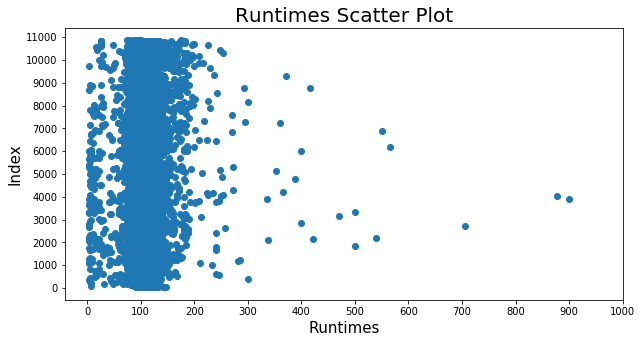

```python
plt.figure(figsize=(10,5))
plt.scatter(y=df.index,x=df.runtime)
plt.title("Runtimes Scatter Plot",fontsize="20")
plt.xlabel("Runtimes",fontsize="15")
plt.ylabel("Index",fontsize="15")
plt.yticks(np.arange(0, 12000, step=1000))
plt.xticks(np.arange(0, 1100, step=100))

plt.show()
```

```python
# finding the threshold value
q=df.runtime.quantile(0.995)
print (q)
```

```
225.0
```

```python
# creating new columns
df['tv_show']=df.runtime[df["runtime"] >   q]
df['movie']=df.runtime[df["runtime"] <   q]
df.head()
```

|  | popularity | original_title | cast | director | keywords | overview | runtime | genres | production_companies | release_date | vote_count | vote_average | release_year | budget_adj | revenue_adj | decades | tv_show | movie |
| --- | --- | --- | --- | --- | --- | --- | --- | --- | --- | --- | --- | --- | --- | --- | --- | --- | --- | --- |
| 25 | 4.5667 | Mission: Impossible - Rogue Nation | Tom Cruise\|Jeremy Renner\|Simon Pegg\|Rebecca Fe... | Christopher McQuarrie | spy\|sequel\|mission | Ethan and team take on their most impossible m... | 131 | Action | Paramount Pictures\|Skydance Productions\|China ... | 7/23/15 | 2349 | 7.1000 | 2015 | 137999939.2800 | 627743451.6729 | [2010, 2020) | nan | 131.0000 |
| 26 | 4.5645 | Ted 2 | Mark Wahlberg\|Seth MacFarlane\|Amanda Seyfried\|... | Seth MacFarlane | sperm bank\|sequel\|buddy\|courthouse\|teddy bear | Newlywed couple Ted and Tami-Lynn want to have... | 115 | Comedy | Universal Pictures\|Media Rights Capital\|Fuzzy ... | 6/25/15 | 1666 | 6.3000 | 2015 | 62559972.4736 | 198594430.1384 | [2010, 2020) | nan | 115.0000 |
| 27 | 4.5038 | Kingsman: The Secret Service | Taron Egerton\|Colin Firth\|Samuel L. Jackson\|Mi... | Matthew Vaughn | spy\|great britain\|secret organization\|secret a... | The story of a super-secret spy organization t... | 130 | Crime\|Comedy\|Action\|Adventure | Twentieth Century Fox Film Corporation\|Marv Fi... | 1/24/15 | 3833 | 7.6000 | 2015 | 74519967.2112 | 371497801.6610 | [2010, 2020) | nan | 130.0000 |
| 28 | 4.0623 | Spotlight | Mark Ruffalo\|Michael Keaton\|Rachel McAdams\|Lie... | Tom McCarthy | child abuse\|journalism\|judge\|florida\|boston | The true story of how The Boston Globe uncover... | 128 | Drama\|Thriller\|History | Participant Media\|Open Road Films\|Anonymous Co... | 11/6/15 | 1559 | 7.8000 | 2015 | 18399991.9040 | 81278719.3974 | [2010, 2020) | nan | 128.0000 |
| 29 | 3.9689 | Maze Runner: The Scorch Trials | Dylan O'Brien\|Kaya Scodelario\|Thomas Brodie-Sa... | Wes Ball | based on novel\|resistance\|maze\|post-apocalypti... | Thomas and his fellow Gladers face their great... | 132 | Action\|Science Fiction\|Thriller | Gotham Group\|Temple Hill Entertainment\|TSG Ent... | 9/9/15 | 1849 | 6.4000 | 2015 | 56119975.3072 | 286356245.9233 | [2010, 2020) | nan | 132.0000 |

```python
#amount of time movie was null so it is a show
show_count=df.movie.isna().sum()

#amount of time show was null so it is a movie
movie_count=df.tv_show.isna().sum()
```

```python
#ratio
movie_count/show_count
```

```
195.2037037037037
```

Which means for every tv-show there are 195 movies , thats how much movies dominate this dataset. As it is our assumption that runtime differentiates movies and shows so it might not be a very good insight but its still worth to look at.

###### Tv shows in each decade

```python
df6=df.copy()
df6.tv_show=df6.tv_show[~df6.tv_show.isna()]
```

```python
tv_show_graph=df6.groupby(['decades']).tv_show.count()
tv_show_graph
```

```
decades
[1960, 1970)     1
[1970, 1980)     0
[1980, 1990)     4
[1990, 2000)     8
[2000, 2010)    22
[2010, 2020)    17
Name: tv_show, dtype: int64
```

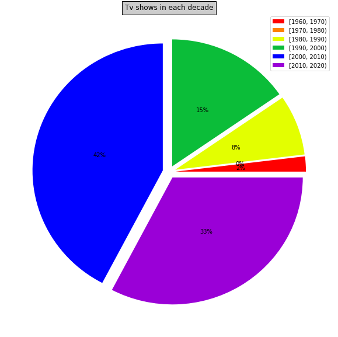

```python
# selecting colors for each division

cmap = plt.cm.prism
colors = cmap(np.linspace(0., 1., 60))

# plotting the results
plt.figure(figsize=(10,10))
plt.pie(tv_show_graph, autopct='%1.0f%%',shadow=False,colors=colors, startangle=0, pctdistance=0.5,explode=(0.05, 0.05, 0.05, 0.05,0.05,0.05));
plt.title("Tv shows in each decade", bbox={'facecolor':'0.8', 'pad':5})
plt.legend(tv_show_graph.index,loc='upper right')
plt.show()
```

## Conclusions

Following were the questions and our analysis of those questions:

##### Q1) How has the popularity and vote count increased in the last few decades.

The modernization of showbiz industry is causing an increase of popularity and vote_Count.The popularity and vote_Count show similar characteristics, movies are popular now than they were few decades ago and hence the vote_Count also increases.

The popularity outliers were removed based on quantile, had they been used, results might have been different. Also relating popularity and vote_count is questionable if you consider that people had almost no mediums to cast votes on movies in the earlier decades but movies were still popular, other than that this insight is pretty sound.

##### Q2) Which decade was the most successful monetarily?

Considering just revenues, the later movies made way more money as compared to the classic movies and the same goes for budget. But the classics had better revenue-budget ratio. Hence the trend shows as the time progresses budget and revenue increases but the profit ratio decreases with few exceptions.

One basic shortcoming of this insight was that we had to fill in mean values where there were zero values, as there were alot of zeros values(more than 50%).

We chose mean because it doesn't affect relationship between the variables and it is very fast. We could have used other imputations but chose mean for the sake of simplicity. These replacements are never perfect because not all missing values are equal to mean and it reduces variance in the dataset.s

##### Q3) What are the most popular genres and keywords of different decades.

Most popular genres were "Drama" and "Comedy".

Most popular keywords were "Based on novels" for earlier decades and "Women Directors" for the recent decades.

The limitation with this result is that we have based the popularity of genre and keywords purely on the number of occurences of each. There can be a lot of drama movies in a decade which have not been well received by the audience hence the popularity will be low even tho count is large.

Also keywords had many null values and they were to be removed to make keywords data usable, results would have been better if all values were non-null from the start.

#### Q4) Which director and actor/actress has been the most successful?

The most successful directors(movies more than 5 and highest mean) are "James Cameron" and "Steven Spielsberg".

The most successful Cast(movies more than 20 and highest mean) are "Will Smith" and "Tom Cruise".

Although we have collected means and counts of movies and have provided sound arguments, the threshold value can be questionable as you get different results with different threshold values and it can never be perfect.

##### Q5) What is the ratio of movies and tv-series in the dataset ? How to differentiate.

The limitation of this insight is that even though we have manually checked that shows do exist in the dataset but the threshold value is an assumption that no movie can be greater than the threshold or no show can be smaller than the threshold. It is very much possible that there are shows that have runtime less than the movies and vice versa which makes the threshold technique wrong. Also our differentiation solely depends on one value (runtime) which is not a good practice when collecting insights.

###### Note:

Although we used almost all the columns for our advantage but their were few which were untouched i.e titles, release_date, production companies etc.Had we predicted that these were not to be used in our analysis , we would have dropped them from the start. This would have made our data more compact and easier to look at.

## Submitting your Project

```python
from subprocess import call
call(['python', '-m', 'nbconvert', 'Investigate_a_Dataset.ipynb'])
```

```
0
```